# **Assignment 7: Ensemble Tree-based Methods**

#### **Topic: Predicting 30-Day Hospital Readmission After Myocardial Infarction Using Ensemble Methods**

In class today, we worked on a Group Exercise to sketch out an analytic pipeline to predict readmission for myocardial infarction. In the assignment, you will implement your pipeline (or a simplified version of it) using a sample dataset.

The dataset (`mi.data`) consists of an ID variable, 14 features describing clinical tests and comorbidities, and an indicator for whether the individual was readmitted to the hospital within 30 days of discharge.

**Feature Information:**

- `readmission`: Readmitted within 30 days — 1: Yes, 0: No (Outcome) [Categorical]
- `Age`: Age at initial MI in years [Continuous]
- `Sex`: Reported by patient — 0: Male, 1: Female, 2: Non-binary/Other [Categorical]
- `sodium`: Serum sodium (mmol/L) [Continuous]
- `ALT`: Liver enzymes (IU/L) [Continuous]
- `WBC`: White blood cell count (billions/L) [Continuous]
- `ESR`: Erythrocyte sedimentation rate [Continuous]
- `SBP`: Systolic blood pressure at intake (mmHg) [Continuous]
- `DBP`: Diastolic blood pressure at intake (mmHg) [Continuous]
- `Pulm.adema`: Pulmonary edema (1=Yes, 0=No) [Categorical]
- `FC`: Functional class of angina pectoris in the last year (0–4) [Categorical]
- `Arr`: Presence of arrhythmia (1=Yes, 0=No) [Categorical]
- `Diab`: Presence of diabetes (1=Yes, 0=No) [Categorical]
- `Obesity`: Presence of obesity (1=Yes, 0=No) [Categorical]
- `Asthma`: Presence of asthma (1=Yes, 0=No) [Categorical]

#### **0. Data Preparation**

**Set up needed libraries**

```r
library(tidyverse)
library(caret)
library(randomForest)
library(gbm)
library(pROC)

set.seed(123)
```

**Import dataset**

```r
mi_df = read_csv(file = "./mi.data.csv")

mi_df = mi_df |> select(-ID)

mi_df
```

```
## # A tibble: 1,700 × 15
##      Age   Sex sodium   ALT   WBC   ESR   SBP   DBP Pulm.adema    FC   Arr  Diab
##    <dbl> <dbl>  <dbl> <dbl> <dbl> <dbl> <dbl> <dbl>      <dbl> <dbl> <dbl> <dbl>
##  1    77     1    138  0.9    8      16   180    90          0     1     0     0
##  2    55     1    132  0.38   7.8     3   140    80          0     0     0     0
##  3    52     1    132  0.3   10.8     4   150   100          0     0     0     0
##  4    68     0    146  0.75  10       5   200   100          0     0     0     0
##  5    60     1    132  0.45   8.3    14   190   100          0     0     0     0
##  6    64     1    130  0.45   7.2     2   220   190          0     2     0     0
##  7    70     1    124  0.3   11.1     5   120    80          0     2     0     0
##  8    65     1    136  0.38   6.2    20   180   100          0     1     0     0
##  9    60     1    131  0.3    6.2     3   200   120          0     0     0     0
## 10    77     0    117  0.38   6.9    30   170    90          0     0     0     1
## # ℹ 1,690 more rows
## # ℹ 3 more variables: Obesity <dbl>, Asthma <dbl>, readmission <dbl>
```

**Clean dataset**

```r
# Check for missing values across all variables before proceeding
miss_count = colSums(is.na(mi_df))
cat("Missing values per variable:\n")
```

```
## Missing values per variable:
```

```r
print(miss_count)
```

```
##         Age         Sex      sodium         ALT         WBC         ESR
##           0           0           0           0           0           0
##         SBP         DBP  Pulm.adema          FC         Arr        Diab
##           0           0           0           0           0           0
##     Obesity      Asthma readmission
##           0           0           0
```

```r
# Retain only complete cases
mi_df = mi_df[complete.cases(mi_df), ]
cat("\nTotal observations after removing missing:", nrow(mi_df), "\n")
```

```
##
## Total observations after removing missing: 1700
```

```r
# Convert binary and ordinal clinical features to factors.
# These are coded as integers (0/1) but represent categories, not quantities.
# Leaving them numeric would imply a false ordering that could mislead the models.
mi_df = mi_df |>
  mutate(
    Sex        = as.factor(Sex),
    Pulm.adema = factor(Pulm.adema, levels = c("0", "1")),
    FC         = factor(FC,         levels = c("0", "1", "2", "3", "4")),
    Arr        = factor(Arr,        levels = c("0", "1")),
    Diab       = factor(Diab,       levels = c("0", "1")),
    Obesity    = factor(Obesity,    levels = c("0", "1")),
    Asthma     = factor(Asthma,     levels = c("0", "1")),
    # Outcome: "No" set as reference level; "Yes" is the positive (event) class
    readmission = factor(ifelse(readmission == 1, "Yes", "No"),
                         levels = c("No", "Yes"))
  )

mi_df
```

```
## # A tibble: 1,700 × 15
##      Age Sex   sodium   ALT   WBC   ESR   SBP   DBP Pulm.adema FC    Arr   Diab
##    <dbl> <fct>  <dbl> <dbl> <dbl> <dbl> <dbl> <dbl> <fct>      <fct> <fct> <fct>
##  1    77 1        138  0.9    8      16   180    90 0          1     0     0
##  2    55 1        132  0.38   7.8     3   140    80 0          0     0     0
##  3    52 1        132  0.3   10.8     4   150   100 0          0     0     0
##  4    68 0        146  0.75  10       5   200   100 0          0     0     0
##  5    60 1        132  0.45   8.3    14   190   100 0          0     0     0
##  6    64 1        130  0.45   7.2     2   220   190 0          2     0     0
##  7    70 1        124  0.3   11.1     5   120    80 0          2     0     0
##  8    65 1        136  0.38   6.2    20   180   100 0          1     0     0
##  9    60 1        131  0.3    6.2     3   200   120 0          0     0     0
## 10    77 0        117  0.38   6.9    30   170    90 0          0     0     1
## # ℹ 1,690 more rows
## # ℹ 3 more variables: Obesity <fct>, Asthma <fct>, readmission <fct>
```

**Overview of continuous features**

```r
mi_df |>
  summarise(across(where(is.numeric),
                   list(Mean = ~round(mean(.), 2),
                        SD   = ~round(sd(.), 2),
                        Min  = ~round(min(.), 2),
                        Max  = ~round(max(.), 2)))) |>
  pivot_longer(everything(),
               names_to  = c("Variable", "Stat"),
               names_sep = "_(?=[^_]+$)") |>
  pivot_wider(names_from  = Stat,
              values_from = value) |>
  knitr::kable(caption = "Table 1: Descriptive Statistics of Continuous Features")
```

Table 1: Descriptive Statistics of Continuous Features

| Variable | Mean | SD | Min | Max |
| --- | --- | --- | --- | --- |
| Age | 61.87 | 11.24 | 26.00 | 92.0 |
| sodium | 136.56 | 6.49 | 117.00 | 169.0 |
| ALT | 0.47 | 0.38 | 0.03 | 3.0 |
| WBC | 8.80 | 3.44 | 2.00 | 27.9 |
| ESR | 13.48 | 11.17 | 1.00 | 140.0 |
| SBP | 138.85 | 34.49 | 0.00 | 260.0 |
| DBP | 82.10 | 19.13 | 0.00 | 190.0 |

**Check outcome balance**

```r
balance_tbl = mi_df |>
  count(readmission) |>
  mutate(Percent = round(100 * n / sum(n), 1))

balance_tbl |>
  knitr::kable(caption = "Table 2: Frequency and Proportion of Readmission Outcome")
```

Table 2: Frequency and Proportion of Readmission Outcome

| readmission | n | Percent |
| --- | --- | --- |
| No | 1541 | 90.6 |
| Yes | 159 | 9.4 |

**NOTE:** From **Table 2**, we observe a substantial class imbalance in the outcome variable, with 90.6% of patients (n = 1,541) classified as not readmitted and only 9.4% (n = 159) readmitted within 30 days of discharge. To prevent models from being biased toward always predicting the majority class (no readmission), **down-sampling** will be applied within each cross-validation fold. This corrects for the imbalance during training without leaking information from held-out folds into the resampling process, and ensures that sensitivity — the model’s ability to correctly identify patients who will truly be readmitted — is not sacrificed in favor of inflated overall accuracy.

**Partition the data into training and testing using a 70/30 split**

```r
set.seed(123)

train_indices = createDataPartition(y = mi_df$readmission, p = 0.7, list = FALSE)
train_data    = mi_df[ train_indices, ]
test_data     = mi_df[-train_indices, ]

split_counts = tibble(
  Dataset = c("Training data", "Testing data"),
  N       = c(nrow(train_data), nrow(test_data)),
  Percent = round(100 * N / nrow(mi_df), 1)
)

split_counts |>
  knitr::kable(caption = "Table 3: Number of Observations in Training and Test Sets")
```

Table 3: Number of Observations in Training and Test Sets

| Dataset | N | Percent |
| --- | --- | --- |
| Training data | 1191 | 70.1 |
| Testing data | 509 | 29.9 |

**NOTE:** A stratified 70/30 split using `createDataPartition()` preserves the proportion of readmitted patients in both sets, yielding 1,191 observations in the training set and 509 in the test set. The test set is set aside completely and will not be examined until final model evaluation in Section 2. All model selection decisions are made using cross-validation performance on the training set only.

All 14 features are retained for modeling based on the following reasoning:

- `Age`, `SBP`, `DBP`, `sodium`, and `WBC` are established clinical indicators of acute cardiac condition severity and physiological stress at admission.
- `ALT` and `ESR` capture liver function and systemic inflammation, both associated with post-AMI recovery trajectory and complication risk.
- `Pulm.adema`, `FC`, and `Arr` reflect direct cardiac complications at admission that are known predictors of adverse post-discharge outcomes.
- `Diab`, `Obesity`, and `Asthma` are comorbidities that increase readmission risk by complicating recovery and elevating vulnerability to secondary events.
- `Sex` is retained to capture potential differences in clinical presentation and outcomes across patient groups.

#### **1. The Comparison of Two Models**

Construct **two prediction models** to predict 30-day readmission using all features. Each model is optimized via cross-validation on the *training data*, and performance is compared before any evaluation on the test set. The two algorithms used are:

- **a) Random Forest** — an ensemble of decision trees built on bootstrapped samples, where each tree uses a random subset of features at each split to reduce correlation between trees.
- **b) Gradient Boosting Machine (GBM)** — an ensemble that grows trees *sequentially*, where each new tree corrects the errors (pseudo-residuals) of the prior model, learning slowly and deliberately to improve prediction.

First, a shared 10-fold cross-validation control is created for use across both models. *Down-sampling* is applied within each fold to correct for class imbalance in the outcome.

```r
train_control = trainControl(
  method          = "cv",
  number          = 10,
  sampling        = "down",        # down-sample majority class within each fold
  classProbs      = TRUE,          # needed to generate predicted probabilities for ROC
  savePredictions = "final"        # saves fold-level predictions for confusionMatrix()
)
```

**a) Random Forest**

A random forest model that tunes `mtry` — the number of features eligible for selection at each split — via 10-fold cross-validation.

```r
set.seed(123)

p = ncol(train_data) - 1   # total number of predictors (all columns minus outcome)

# Three mtry values tested, following the lecture demo approach:
#   p       → equivalent to bagging (all features at each split, trees are correlated)
#   sqrt(p) → standard recommendation for RF classification tasks
#   0.5*p   → intermediate de-correlation between bagging and full RF
mtry_vals = c(p, round(sqrt(p)), round(0.5 * p))
mtry_grid  = expand.grid(.mtry = mtry_vals)

model_rf = train(
  readmission ~ .,
  data      = train_data,
  method    = "rf",
  metric    = "Accuracy",
  tuneGrid  = mtry_grid,
  trControl = train_control,
  ntree     = 500            # 500 trees — RF does not overfit with more trees
)

# Best mtry value selected by cross-validation
model_rf$bestTune
```

```
##   mtry
## 1    4
```

```r
# CV accuracy for each mtry value tested
model_rf$results
```

```
##   mtry  Accuracy      Kappa AccuracySD    KappaSD
## 1    4 0.5725423 0.06219520 0.03396354 0.06232934
## 2    7 0.5601001 0.05397269 0.03950449 0.05531542
## 3   14 0.5573749 0.04096867 0.05976984 0.06516931
```

```r
# Variable importance: accuracy-based OOB importance
# Measures how much prediction accuracy drops when each variable is randomly permuted
varImp(model_rf)
```

```
## rf variable importance
##
##              Overall
## WBC         100.0000
## Age          86.5462
## sodium       76.7956
## ESR          72.9607
## ALT          70.3522
## SBP          63.1803
## DBP          46.4616
## FC2          19.6074
## Sex1         17.1034
## Diab1        10.6359
## FC3           5.1345
## Pulm.adema1   4.9943
## Obesity1      4.7368
## Arr1          3.0981
## Asthma1       2.4588
## FC1           2.2350
## FC4           0.6107
## Sex2          0.0000
```

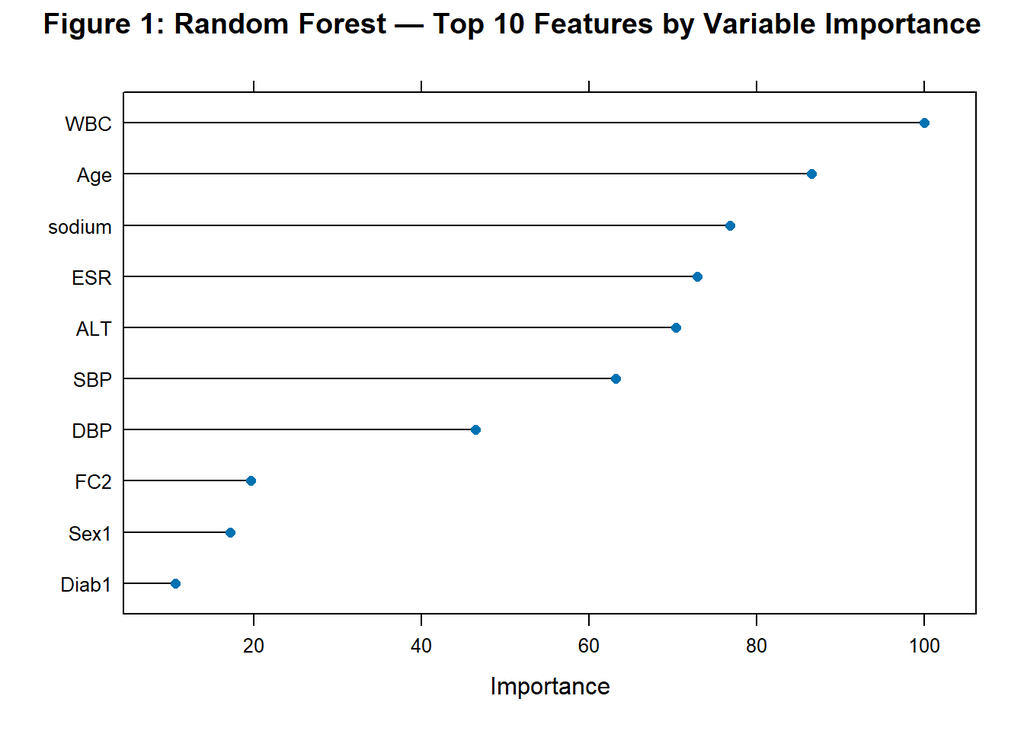

```r
plot(varImp(model_rf), top = 10,
     main = "Figure 1: Random Forest — Top 10 Features by Variable Importance")
```

[figure not shown]

```r
# Both MeanDecreaseAccuracy and MeanDecreaseGini displayed side by side
varImpPlot(model_rf$finalModel,
           main = "Figure 2: Random Forest — Variable Importance (Both Measures)")
```

```r
# Cross-validated confusion matrix from training folds
confusionMatrix(model_rf)
```

```
## Cross-Validated (10 fold) Confusion Matrix
##
## (entries are percentual average cell counts across resamples)
##
##           Reference
## Prediction   No  Yes
##        No  51.6  3.8
##        Yes 39.0  5.6
##
##  Accuracy (average) : 0.5726
```

**b) Gradient Boosting Machine (GBM)**

```r
set.seed(123)

# Hyperparameter tuning grid:
#   n.trees:           number of sequential boosting iterations
#   shrinkage:         learning rate — smaller = slower learning, requires more trees
#                      0.01 and 0.001 are typical starting values from lecture
#   interaction.depth: d=1 → stumps (additive model, no interactions) — weak learner approach
#                      d=3 → allows 3-way interactions, more complex
#   n.minobsinnode:    minimum cases per terminal node, controls tree size
grid_gbm = expand.grid(
  n.trees           = c(100, 200, 300, 500),
  shrinkage         = c(0.01, 0.001),
  interaction.depth = c(1, 3),
  n.minobsinnode    = 10
)

model_gbm = train(
  readmission ~ .,
  data         = train_data,
  method       = "gbm",
  distribution = "bernoulli",   # bernoulli distribution for binary classification
  metric       = "Accuracy",
  tuneGrid     = grid_gbm,
  trControl    = train_control,
  verbose      = FALSE          # suppress per-iteration output
)

# Best hyperparameter combination selected by CV
model_gbm$bestTune
```

```
##    n.trees interaction.depth shrinkage n.minobsinnode
## 16     500                 3      0.01             10
```

```r
# Top CV results — look for selected shrinkage and interaction depth
model_gbm$results |>
  arrange(desc(Accuracy)) |>
  select(n.trees, shrinkage, interaction.depth, Accuracy, Kappa) |>
  head(10)
```

```
##    n.trees shrinkage interaction.depth  Accuracy      Kappa
## 1      500     0.010                 3 0.5576066 0.01919136
## 2      300     0.010                 3 0.5542594 0.02490800
## 3      200     0.010                 3 0.5542312 0.02500578
## 4      100     0.010                 3 0.5398749 0.02041113
## 5      500     0.001                 3 0.5323464 0.04512706
## 6      100     0.001                 3 0.5314706 0.03658254
## 7      300     0.001                 3 0.5289497 0.04371707
## 8      100     0.010                 1 0.5265626 0.04160511
## 9      200     0.001                 3 0.5247055 0.04166403
## 10     300     0.001                 1 0.5215690 0.03372648
```

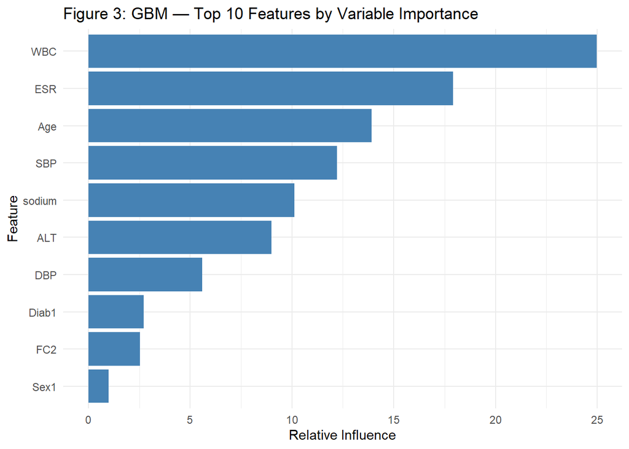

```r
# Variable importance via gbm summary — relative influence per feature
gbm_imp = summary(model_gbm$finalModel,
                  n.trees = model_gbm$bestTune$n.trees,
                  plotit  = FALSE)

gbm_imp |>
  slice_max(rel.inf, n = 10) |>
  ggplot(aes(x = rel.inf, y = reorder(var, rel.inf))) +
  geom_col(fill = "steelblue") +
  labs(x     = "Relative Influence",
       y     = "Feature",
       title = "Figure 3: GBM — Top 10 Features by Variable Importance") +
  theme_minimal()
```

```r
# Cross-validated confusion matrix from training folds
confusionMatrix(model_gbm)
```

```
## Cross-Validated (10 fold) Confusion Matrix
##
## (entries are percentual average cell counts across resamples)
##
##           Reference
## Prediction   No  Yes
##        No  51.1  4.8
##        Yes 39.5  4.6
##
##  Accuracy (average) : 0.5575
```

#### **2. Model Selection**

Select an “optimal” model and calculate final evaluation metrics in the test set. **Only one model should be applied to the test set.** What do you conclude about your final model’s performance?

**Compare Models on Training Performance**

```r
results = resamples(list(
  RandomForest = model_rf,
  GBM          = model_gbm
))

summary(results)
```

```
##
## Call:
## summary.resamples(object = results)
##
## Models: RandomForest, GBM
## Number of resamples: 10
##
## Accuracy
##                   Min.   1st Qu.    Median      Mean   3rd Qu.      Max. NA's
## RandomForest 0.5169492 0.5567227 0.5732143 0.5725423 0.5924370 0.6218487    0
## GBM          0.4833333 0.5336134 0.5648109 0.5576066 0.5798319 0.6101695    0
##
## Kappa
##                     Min.     1st Qu.      Median       Mean    3rd Qu.
## RandomForest -0.03764270  0.01451368 0.088121118 0.06219520 0.09933619
## GBM          -0.06768456 -0.02638790 0.005991122 0.01919136 0.07457671
##                   Max. NA's
## RandomForest 0.1417910    0
## GBM          0.1402769    0
```

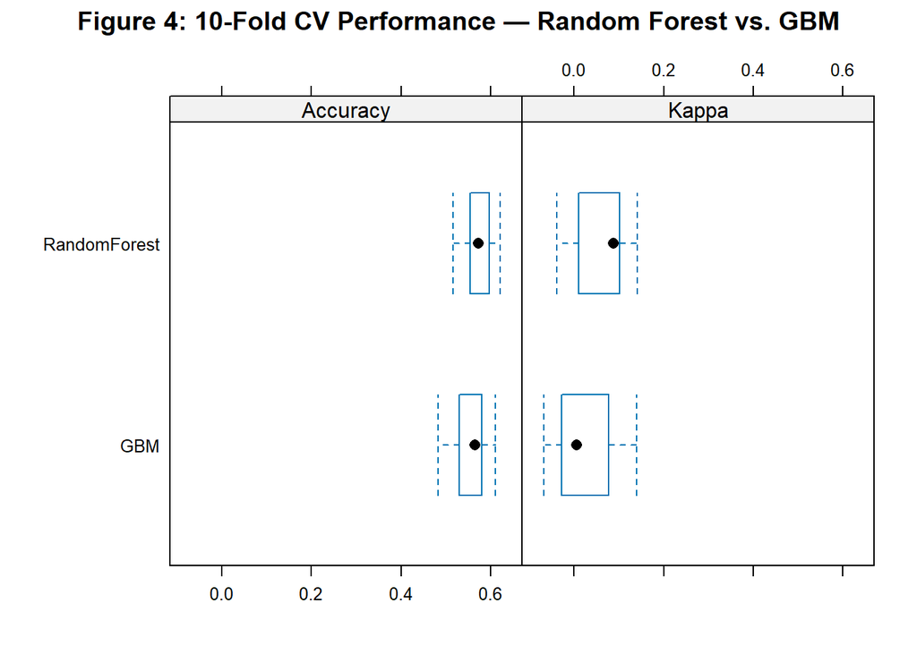

```r
bwplot(results,
       main = "Figure 4: 10-Fold CV Performance — Random Forest vs. GBM")
```

**Final Model Evaluation (Test Set)**

The final Random Forest model is applied once to the held-out test set to report unbiased evaluation metrics.

```r
set.seed(123)

final_model = model_rf

final_pred = predict(final_model, newdata = test_data)

confusionMatrix(final_pred, test_data$readmission, positive = "Yes")
```

```
## Confusion Matrix and Statistics
##
##           Reference
## Prediction  No Yes
##        No  238  20
##        Yes 224  27
##
##                Accuracy : 0.5206
##                  95% CI : (0.4762, 0.5648)
##     No Information Rate : 0.9077
##     P-Value [Acc > NIR] : 1
##
##                   Kappa : 0.0304
##
##  Mcnemar's Test P-Value : <2e-16
##
##             Sensitivity : 0.57447
##             Specificity : 0.51515
##          Pos Pred Value : 0.10757
##          Neg Pred Value : 0.92248
##              Prevalence : 0.09234
##          Detection Rate : 0.05305
##    Detection Prevalence : 0.49312
##       Balanced Accuracy : 0.54481
##
##        'Positive' Class : Yes
##
```

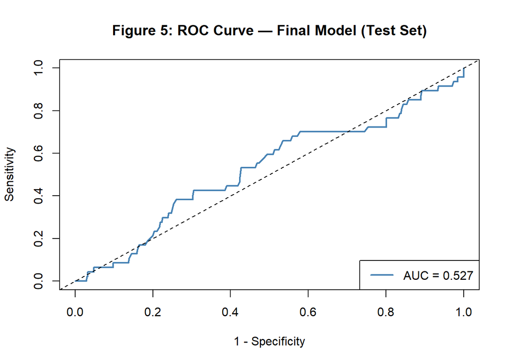

```r
final_pred_prob = predict(final_model, newdata = test_data, type = "prob")

roc_analysis = roc(
  response  = test_data$readmission,
  predictor = final_pred_prob[, "Yes"]
)

plot(
  1 - roc_analysis$specificities,
  roc_analysis$sensitivities,
  type = "l", col = "steelblue", lwd = 2,
  ylab = "Sensitivity",
  xlab = "1 - Specificity",
  main = "Figure 5: ROC Curve — Final Model (Test Set)"
)
abline(a = 0, b = 1, lty = 2)
legend("bottomright",
       legend = paste("AUC =", round(auc(roc_analysis), 3)),
       col    = "steelblue", lwd = 2)
```

```r
cat("Test Set AUC:", round(auc(roc_analysis), 3), "\n")
```

```
## Test Set AUC: 0.527
```

**Variable Importance — Final Model**

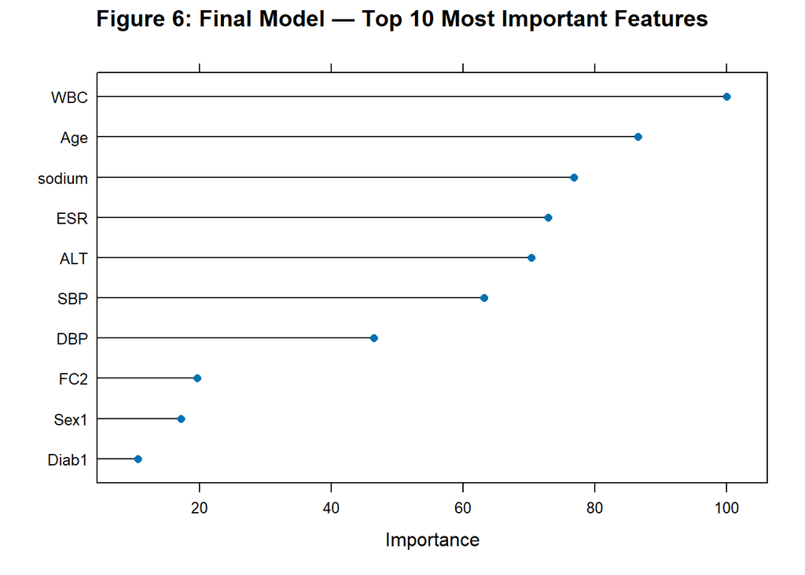

```r
plot(varImp(final_model), top = 10,
     main = "Figure 6: Final Model — Top 10 Most Important Features")
```

```r
varImp(final_model)
```

```
## rf variable importance
##
##              Overall
## WBC         100.0000
## Age          86.5462
## sodium       76.7956
## ESR          72.9607
## ALT          70.3522
## SBP          63.1803
## DBP          46.4616
## FC2          19.6074
## Sex1         17.1034
## Diab1        10.6359
## FC3           5.1345
## Pulm.adema1   4.9943
## Obesity1      4.7368
## Arr1          3.0981
## Asthma1       2.4588
## FC1           2.2350
## FC4           0.6107
## Sex2          0.0000
```

#### **3. Reflection: Comparing Random Forest and GBM in a Clinical Setting**

In this analysis, we compared two ensemble tree-based methods — random forest and gradient boosting — to predict 30-day AMI readmission. Briefly discuss one key conceptual difference between these two methods and how that difference may affect their suitability for clinical prediction.

**Answer:** Random forest and gradient boosting differ fundamentally in how trees are built and combined. In random forest, trees are grown *in parallel* and independently on bootstrapped samples of the training data, and predictions are averaged across all trees. This parallel structure makes random forest robust to noise and less prone to overfitting, since errors in individual trees tend to cancel out. In gradient boosting, trees are grown *sequentially*, with each new tree specifically targeting the residual errors left by the previous model. This allows GBM to reduce bias systematically and capture complex patterns in the data, but also makes it more sensitive to hyperparameter choices and more computationally demanding to tune. In a clinical prediction context with a relatively small sample size — as in this AMI readmission dataset — random forest’s greater stability may be advantageous, whereas GBM’s flexibility can yield higher performance when there is sufficient data and careful tuning. The choice ultimately depends on whether the clinical priority is robustness and consistency or maximizing discriminative performance.